# **Semistructured Merge on Open Source Projects**

- [RAW Results and Logs](https://github.com/spgroup/conflict-patterns/tree/master/isi/results-log-raw-oss.zip)

## How often conflicts occur with semistructured and unstructured merge?

There is a difference of **24.49%** in the number of reported conflicts.

|  | Semistructured Merge | Unstructured Merge |
| --- | --- | --- |
| 1 | 2058 | 2562 |

Merge scenarios had at least one conflict with *semistructured* merge on average **5.66%** of the considered merge scenarios, with a standard deviation of **5.39%** . Considering aggregated numbers of all projects of our sample, this corresponds to **5.64%** of the considered merge scenarios. Besides that, merge scenarios had at least one conflict with *unstructured* merge on average **6.52%** of the considered merge scenarios, with a standard deviation of **6.22%** . Considering aggregated numbers of all projects of our sample, this corresponds to **6.5%** of the considered merge scenarios.

|  | Project | Merge Scenarios | Conflicting Semistructured Merge Scenarios | Conflicting Unstructured Merge Scenarios |
| --- | --- | --- | --- | --- |
| 1 | jitsi | 94 | 2 | 2 |
| 2 | groovy-core | 678 | 28 | 35 |
| 3 | graylog2-server | 1079 | 50 | 68 |
| 4 | junit | 385 | 32 | 35 |
| 5 | jedis | 341 | 47 | 58 |
| 6 | retrofit | 526 | 2 | 3 |
| 7 | netty | 171 | 6 | 8 |
| 8 | okhttp | 1224 | 16 | 3 |
| 9 | commafeed | 247 | 1 | 2 |
| 10 | rundeck | 662 | 3 | 5 |

[output cut: 8 more lines]

## How long does take semistructured and unstructured merge?

|  | Semistructured Merge | Unstructured Merge |
| --- | --- | --- |
| 1 | 549.33 | 111.09 |

## How often semistructured and unstructured merge differ?

### By All Scenarios

The tools differ on average **2.19%** of the considered merge scenarios, with a standard deviation of **2.45%** . Considering aggregated numbers of all projects of our sample, this corresponds to **2.49%** of the considered merge scenarios.

|  | Project | Merge Scenarios | Conflicting Merge Scenarios Only With Semistructured Merge | Conflicting Merge Scenarios Only With Unstructured Merge | % |
| --- | --- | --- | --- | --- | --- |
| 1 | jitsi | 94 | 0 | 0 | 0 |
| 2 | groovy-core | 678 | 4 | 11 | 2.21 |
| 3 | graylog2-server | 1079 | 1 | 19 | 1.85 |
| 4 | junit | 385 | 3 | 6 | 2.34 |
| 5 | jedis | 341 | 6 | 17 | 6.75 |
| 6 | retrofit | 526 | 0 | 1 | 0.19 |
| 7 | netty | 171 | 1 | 3 | 2.33 |
| 8 | okhttp | 1224 | 13 | 0 | 1.06 |
| 9 | commafeed | 247 | 0 | 1 | 0.4 |
| 10 | rundeck | 662 | 0 | 2 | 0.3 |

[output cut: 8 more lines]

### By Conflicting Scenarios

|  | Project | Conflicting Merge Scenarios | Conflicting Merge Scenarios Only With Semistructured Merge | Conflicting Merge Scenarios Only With Unstructured Merge | % |
| --- | --- | --- | --- | --- | --- |
| 1 | jitsi | 2 | 0 | 0 | 0 |
| 2 | groovy-core | 39 | 4 | 11 | 38.47 |
| 3 | graylog2-server | 69 | 1 | 19 | 28.99 |
| 4 | junit | 38 | 3 | 6 | 23.68 |
| 5 | jedis | 64 | 6 | 17 | 35.94 |
| 6 | retrofit | 3 | 0 | 1 | 33.33 |
| 7 | netty | 9 | 1 | 3 | 44.44 |
| 8 | okhttp | 16 | 13 | 0 | 81.25 |
| 9 | commafeed | 2 | 0 | 1 | 50 |
| 10 | rundeck | 5 | 0 | 2 | 40 |

[output cut: 8 more lines]

### Boxplot

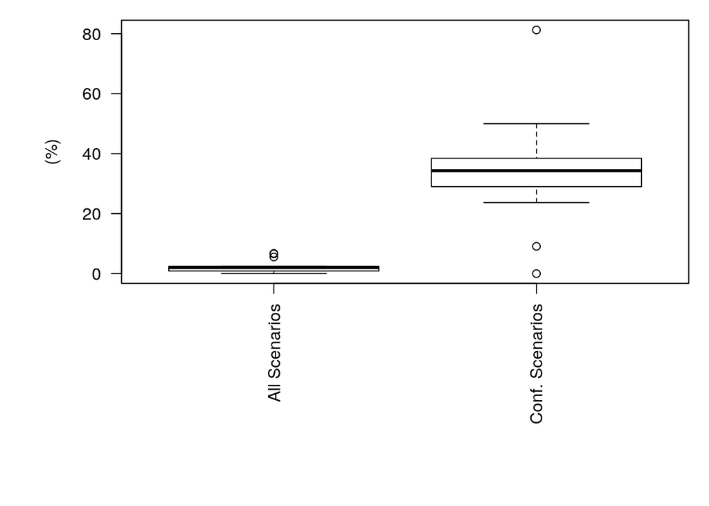

## When compared to semistructured merge, does unstructured merge reduce unnecessary integration effort by reporting fewer false positives?

### Semistructured Merge Additional False Positives

#### By All Scenarios

On average **1.76%** of the considered merge scenarios, had semistructured merge additional falses positives, with a standard deviation of **1.62%** . Considering aggregated numbers of all projects of our sample, this corresponds to **1.66%** of the considered merge scenarios.

|  | Project | Merge Scenarios | Merge Scenarios with Renaming Conflicts | Merge Scenarios with Deletion Conflicts | % |
| --- | --- | --- | --- | --- | --- |
| 1 | jitsi | 94 | 2 | 0 | 2.13 |
| 2 | groovy-core | 678 | 6 | 0 | 0.88 |
| 3 | graylog2-server | 1079 | 16 | 0 | 1.48 |
| 4 | junit | 385 | 7 | 0 | 1.82 |
| 5 | jedis | 341 | 16 | 0 | 4.69 |
| 6 | retrofit | 526 | 1 | 0 | 0.19 |
| 7 | netty | 171 | 2 | 0 | 1.17 |
| 8 | okhttp | 1224 | 4 | 0 | 0.33 |
| 9 | commafeed | 247 | 0 | 0 | 0 |
| 10 | rundeck | 662 | 0 | 0 | 0 |

[output cut: 8 more lines]

#### By Conflicts

On average **18.02%** of the number of semistructured merge reported conflicts are additional falses positives, with a standard deviation of **17.41%** . Considering aggregated numbers of all projects of our sample, this corresponds to **14.09%** of the number of semistructured merge reported conflicts.

|  | Project | Conflicts | Renaming Conflicts | Deletion Conflicts | % |
| --- | --- | --- | --- | --- | --- |
| 1 | jitsi | 13 | 7 | 0 | 53.85 |
| 2 | groovy-core | 173 | 6 | 0 | 3.47 |
| 3 | graylog2-server | 116 | 29 | 0 | 25 |
| 4 | junit | 86 | 10 | 0 | 11.63 |
| 5 | jedis | 441 | 42 | 0 | 9.52 |
| 6 | retrofit | 16 | 2 | 0 | 12.5 |
| 7 | netty | 59 | 31 | 0 | 52.54 |
| 8 | okhttp | 23 | 5 | 0 | 21.74 |
| 9 | commafeed | 1 | 0 | 0 | 0 |
| 10 | rundeck | 8 | 0 | 0 | 0 |

[output cut: 8 more lines]

### Unstructured Merge Additional False Positives

#### By All Scenarios

On average **4.24%** of the considered merge scenarios, had unstructured merge additional falses positives, with a standard deviation of **4.49%** . Considering aggregated numbers of all projects of our sample, this corresponds to **4.27%** of the considered merge scenarios.

|  | Project | Merge Scenarios | Merge Scenarios with Unstructured Merge Additional False Positives * | % |
| --- | --- | --- | --- | --- |
| 1 | jitsi | 94 | 2 | 2.13 |
| 2 | groovy-core | 678 | 18 | 2.65 |
| 3 | graylog2-server | 1079 | 45 | 4.17 |
| 4 | junit | 385 | 16 | 4.16 |
| 5 | jedis | 341 | 44 | 12.9 |
| 6 | retrofit | 526 | 2 | 0.38 |
| 7 | netty | 171 | 5 | 2.92 |
| 8 | okhttp | 1224 | 1 | 0.08 |
| 9 | commafeed | 247 | 1 | 0.4 |
| 10 | rundeck | 662 | 3 | 0.45 |

[output cut: 8 more lines]

#### By Conflicts

On average **40.89%** of the number of unstructured merge reported conflicts are additional falses positives, with a standard deviation of **13.94%** . Considering aggregated numbers of all projects of our sample, this corresponds to **45.63%** of the number of unstructured merge reported conflicts.

|  | Project | Conflicts | Ordering Conflicts | % |
| --- | --- | --- | --- | --- |
| 1 | jitsi | 18 | 7 | 38.89 |
| 2 | groovy-core | 191 | 30 | 15.71 |
| 3 | graylog2-server | 231 | 134 | 58.01 |
| 4 | junit | 121 | 45 | 37.19 |
| 5 | jedis | 416 | 185 | 44.47 |
| 6 | retrofit | 29 | 14 | 48.28 |
| 7 | netty | 125 | 73 | 58.4 |
| 8 | okhttp | 8 | 1 | 12.5 |
| 9 | commafeed | 2 | 1 | 50 |
| 10 | rundeck | 15 | 7 | 46.67 |

[output cut: 8 more lines]

Statistical significance **by scenarios**, consider a confidence level of 0.95 (p-value = 0.05):

```
##
##  Wilcoxon signed rank test with continuity correction
##
## data:  aFP_ST$unstructured and aFP_SS$Semistructured
## V = 99, p-value = 0.00388
## alternative hypothesis: true location shift is not equal to 0
```

Strength/magnitude of the statistical claim (*effect size*) **by scenarios**:

```
##
## Cliff's Delta
##
## delta estimate: 0.3377778 (medium)
## 95 percent confidence interval:
##       lower       upper
## -0.09307555  0.66208097
```

Statistical significance **by conflicts**, consider a confidence level of 0.95 (p-value = 0.05):

```
##
##  Wilcoxon signed rank test
##
## data:  aFP_ST$unstructured and aFP_SS$Semistructured
## V = 110, p-value = 0.002625
## alternative hypothesis: true location shift is not equal to 0
```

Strength/magnitude of the statistical claim (*effect size*) **by conflicts**:

```
##
## Cliff's Delta
##
## delta estimate: 0.6844444 (large)
## 95 percent confidence interval:
##     lower     upper
## 0.2672163 0.8855660
```

## When compared to semistructured merge, does unstructured merge compromise integration correctness by having more false negatives?

### Semistructured Merge Additional False Negatives

#### By All Scenarios

On average **3.25%** of the considered merge scenarios, had semistructured merge additional falses negatives, with a standard deviation of **3.49%** . Considering aggregated numbers of all projects of our sample, this corresponds to **3%** of the considered merge scenarios.

|  | Project | Merge Scenarios | Merge Scenarios with Type Ambiguity Errors | Merge Scenarios with References between New and Edited Elements | Merge Scenarios with Initialization Blocks | Merge Scenarios with Acidental Conflicts | % |
| --- | --- | --- | --- | --- | --- | --- | --- |
| 1 | jitsi | 94 | 0 | 0 | 0 | 2 | 2.13 |
| 2 | groovy-core | 678 | 0 | 0 | 1 | 11 | 1.77 |
| 3 | graylog2-server | 1079 | 0 | 0 | 0 | 32 | 2.97 |
| 4 | junit | 385 | 0 | 0 | 0 | 14 | 3.64 |
| 5 | jedis | 341 | 0 | 2 | 0 | 34 | 10.56 |
| 6 | retrofit | 526 | 0 | 0 | 0 | 1 | 0.19 |
| 7 | netty | 171 | 0 | 0 | 0 | 4 | 2.34 |
| 8 | okhttp | 1224 | 0 | 0 | 0 | 1 | 0.08 |
| 9 | commafeed | 247 | 0 | 0 | 0 | 0 | 0 |
| 10 | rundeck | 662 | 0 | 0 | 0 | 1 | 0.15 |

[output cut: 8 more lines]

#### By Conflicts

On average **34.4%** of the number of semistructured merge conflicts are semistructured merge additional falses negatives, with a standard deviation of **20.32%** . Considering aggregated numbers of all projects of our sample, this corresponds to **30.32%** of the number of semistructured merge conflicts.

|  | Project | Conflicts | Type Ambiguity Errors | References between New and Edited Elements | Initialization Blocks | Acidental Conflicts | % |
| --- | --- | --- | --- | --- | --- | --- | --- |
| 1 | jitsi | 13 | 0 | 0 | 0 | 7 | 53.85 |
| 2 | groovy-core | 173 | 0 | 0 | 1 | 17 | 10.41 |
| 3 | graylog2-server | 116 | 0 | 0 | 0 | 58 | 50 |
| 4 | junit | 86 | 0 | 0 | 0 | 36 | 41.86 |
| 5 | jedis | 441 | 0 | 2 | 0 | 116 | 26.75 |
| 6 | retrofit | 16 | 0 | 0 | 0 | 8 | 50 |
| 7 | netty | 59 | 0 | 0 | 0 | 43 | 72.88 |
| 8 | okhttp | 23 | 0 | 0 | 0 | 1 | 4.35 |
| 9 | commafeed | 1 | 0 | 0 | 0 | 0 | 0 |
| 10 | rundeck | 8 | 0 | 0 | 0 | 4 | 50 |

[output cut: 8 more lines]

### Unstructured Merge Additional False Negatives

#### By All Scenarios

On average **0.32%** of the considered merge scenarios, had unstructured merge additional falses negatives, with a standard deviation of **0.49%** . Considering aggregated numbers of all projects of our sample, this corresponds to **0.36%** of the considered merge scenarios.

|  | Project | Merge Scenarios | Merge Scenarios with Duplicated Declaration Errors | % |
| --- | --- | --- | --- | --- |
| 1 | jitsi | 94 | 0 | 0 |
| 2 | groovy-core | 678 | 0 | 0 |
| 3 | graylog2-server | 1079 | 4 | 0.37 |
| 4 | junit | 385 | 0 | 0 |
| 5 | jedis | 341 | 3 | 0.88 |
| 6 | retrofit | 526 | 0 | 0 |
| 7 | netty | 171 | 2 | 1.17 |
| 8 | okhttp | 1224 | 0 | 0 |
| 9 | commafeed | 247 | 0 | 0 |
| 10 | rundeck | 662 | 0 | 0 |

[output cut: 8 more lines]

#### By Conflicts

On average **1.24%** of the number of unstructured merge conflicts are unstructured merge additional falses negatives, with a standard deviation of **1.74%** . Considering aggregated numbers of all projects of our sample, this corresponds to **2.34%** of the number of unstructured merge conflicts.

|  | Project | Conflicts | Duplicated Declaration Errors | % |
| --- | --- | --- | --- | --- |
| 1 | jitsi | 18 | 0 | 0 |
| 2 | groovy-core | 191 | 0 | 0 |
| 3 | graylog2-server | 231 | 6 | 2.6 |
| 4 | junit | 121 | 0 | 0 |
| 5 | jedis | 416 | 13 | 3.12 |
| 6 | retrofit | 29 | 0 | 0 |
| 7 | netty | 125 | 3 | 2.4 |
| 8 | okhttp | 8 | 0 | 0 |
| 9 | commafeed | 2 | 0 | 0 |
| 10 | rundeck | 15 | 0 | 0 |

[output cut: 8 more lines]

Statistical significance **by scenarios**, consider a confidence level of 0.95 (p-value = 0.05):

```
##
##  Wilcoxon signed rank test with continuity correction
##
## data:  aFN_SS$Semistructured and aFN_UN$Unstructured
## V = 105, p-value = 0.001097
## alternative hypothesis: true location shift is not equal to 0
```

Strength/magnitude of the statistical claim (*effect size*) **by scenarios**:

```
##
## Cliff's Delta
##
## delta estimate: 0.72 (large)
## 95 percent confidence interval:
##     lower     upper
## 0.3522688 0.8951494
```

Statistical significance **by conflicts**, consider a confidence level of 0.95 (p-value = 0.05):

```
##
##  Wilcoxon signed rank test with continuity correction
##
## data:  aFN_SS$Semistructured and aFN_UN$Unstructured
## V = 105, p-value = 0.001094
## alternative hypothesis: true location shift is not equal to 0
```

Strength/magnitude of the statistical claim (*effect size*) **by conflicts**:

```
##
## Cliff's Delta
##
## delta estimate: 0.8977778 (large)
## 95 percent confidence interval:
##     lower     upper
## 0.5291413 0.9813313
```

#### Summary False Positives and False Negatives

|  |  | Semistructured Merge | Unstructured Merge |
| --- | --- | --- | --- |
| 1 | aFP | 290 | 1169 |
| 2 | aFN | 624 | 60 |